# Risk Factor Analysis

## Outcome Variable

**Outcome Variable:** sstunted

## Predictor Variables

**Intervention Variable:** rain_quartile

**Adjustment Set:**

unadjusted

## Stratifying Variables

The analysis was stratified on these variable(s):

- studyid
- country
- agecat

## Data Summary

| studyid | country | agecat | rain_quartile | sstunted | n_cell | n | outcome_variable |
| --- | --- | --- | --- | --- | --- | --- | --- |
| CMC-V-BCS-2002 | India | Birth | 1 | 0 | 17 | 92 | sstunted |
| CMC-V-BCS-2002 | India | Birth | 1 | 1 | 1 | 92 | sstunted |
| CMC-V-BCS-2002 | India | Birth | 2 | 0 | 23 | 92 | sstunted |
| CMC-V-BCS-2002 | India | Birth | 2 | 1 | 2 | 92 | sstunted |
| CMC-V-BCS-2002 | India | Birth | 3 | 0 | 30 | 92 | sstunted |
| CMC-V-BCS-2002 | India | Birth | 3 | 1 | 0 | 92 | sstunted |
| CMC-V-BCS-2002 | India | Birth | 4 | 0 | 18 | 92 | sstunted |
| CMC-V-BCS-2002 | India | Birth | 4 | 1 | 1 | 92 | sstunted |
| CMC-V-BCS-2002 | India | 6 months | 1 | 0 | 86 | 369 | sstunted |
| CMC-V-BCS-2002 | India | 6 months | 1 | 1 | 15 | 369 | sstunted |
| CMC-V-BCS-2002 | India | 6 months | 2 | 0 | 97 | 369 | sstunted |
| CMC-V-BCS-2002 | India | 6 months | 2 | 1 | 14 | 369 | sstunted |
| CMC-V-BCS-2002 | India | 6 months | 3 | 0 | 88 | 369 | sstunted |
| CMC-V-BCS-2002 | India | 6 months | 3 | 1 | 9 | 369 | sstunted |
| CMC-V-BCS-2002 | India | 6 months | 4 | 0 | 56 | 369 | sstunted |
| CMC-V-BCS-2002 | India | 6 months | 4 | 1 | 4 | 369 | sstunted |
| CMC-V-BCS-2002 | India | 24 months | 1 | 0 | 52 | 333 | sstunted |
| CMC-V-BCS-2002 | India | 24 months | 1 | 1 | 35 | 333 | sstunted |
| CMC-V-BCS-2002 | India | 24 months | 2 | 0 | 49 | 333 | sstunted |
| CMC-V-BCS-2002 | India | 24 months | 2 | 1 | 41 | 333 | sstunted |
| CMC-V-BCS-2002 | India | 24 months | 3 | 0 | 63 | 333 | sstunted |
| CMC-V-BCS-2002 | India | 24 months | 3 | 1 | 31 | 333 | sstunted |
| CMC-V-BCS-2002 | India | 24 months | 4 | 0 | 39 | 333 | sstunted |
| CMC-V-BCS-2002 | India | 24 months | 4 | 1 | 23 | 333 | sstunted |
| CMIN | Bangladesh | Birth | 1 | 0 | 5 | 26 | sstunted |
| CMIN | Bangladesh | Birth | 1 | 1 | 2 | 26 | sstunted |
| CMIN | Bangladesh | Birth | 2 | 0 | 5 | 26 | sstunted |
| CMIN | Bangladesh | Birth | 2 | 1 | 1 | 26 | sstunted |
| CMIN | Bangladesh | Birth | 3 | 0 | 5 | 26 | sstunted |
| CMIN | Bangladesh | Birth | 3 | 1 | 1 | 26 | sstunted |

[output cut: 506 more lines]

The following strata were considered:

- studyid: CMC-V-BCS-2002, country: India, agecat: 24 months
- studyid: CMC-V-BCS-2002, country: India, agecat: 6 months
- studyid: CMC-V-BCS-2002, country: India, agecat: Birth
- studyid: CMIN, country: Bangladesh, agecat: 24 months
- studyid: CMIN, country: Bangladesh, agecat: 6 months
- studyid: CMIN, country: Bangladesh, agecat: Birth
- studyid: CONTENT, country: Peru, agecat: 24 months
- studyid: CONTENT, country: Peru, agecat: 6 months
- studyid: CONTENT, country: Peru, agecat: Birth
- studyid: EE, country: Pakistan, agecat: 24 months
- studyid: EE, country: Pakistan, agecat: 6 months
- studyid: EE, country: Pakistan, agecat: Birth
- studyid: GMS-Nepal, country: Nepal, agecat: 24 months
- studyid: GMS-Nepal, country: Nepal, agecat: 6 months
- studyid: GMS-Nepal, country: Nepal, agecat: Birth
- studyid: Guatemala BSC, country: Guatemala, agecat: 6 months
- studyid: IRC, country: India, agecat: 24 months
- studyid: IRC, country: India, agecat: 6 months
- studyid: IRC, country: India, agecat: Birth
- studyid: JiVitA-3, country: Bangladesh, agecat: 24 months
- studyid: JiVitA-3, country: Bangladesh, agecat: 6 months
- studyid: JiVitA-3, country: Bangladesh, agecat: Birth
- studyid: JiVitA-4, country: Bangladesh, agecat: 24 months
- studyid: JiVitA-4, country: Bangladesh, agecat: 6 months
- studyid: JiVitA-4, country: Bangladesh, agecat: Birth
- studyid: Keneba, country: Gambia, agecat: 24 months
- studyid: Keneba, country: Gambia, agecat: 6 months
- studyid: Keneba, country: Gambia, agecat: Birth
- studyid: LCNI-5, country: Malawi, agecat: 24 months
- studyid: LCNI-5, country: Malawi, agecat: 6 months
- studyid: MAL-ED, country: Bangladesh, agecat: 24 months
- studyid: MAL-ED, country: Bangladesh, agecat: 6 months
- studyid: MAL-ED, country: Bangladesh, agecat: Birth
- studyid: MAL-ED, country: Brazil, agecat: 24 months
- studyid: MAL-ED, country: Brazil, agecat: 6 months
- studyid: MAL-ED, country: Brazil, agecat: Birth
- studyid: MAL-ED, country: India, agecat: 24 months
- studyid: MAL-ED, country: India, agecat: 6 months
- studyid: MAL-ED, country: India, agecat: Birth
- studyid: MAL-ED, country: Nepal, agecat: 24 months
- studyid: MAL-ED, country: Nepal, agecat: 6 months
- studyid: MAL-ED, country: Nepal, agecat: Birth
- studyid: MAL-ED, country: Peru, agecat: 24 months
- studyid: MAL-ED, country: Peru, agecat: 6 months
- studyid: MAL-ED, country: Peru, agecat: Birth
- studyid: MAL-ED, country: South Africa, agecat: 24 months
- studyid: MAL-ED, country: South Africa, agecat: 6 months
- studyid: MAL-ED, country: South Africa, agecat: Birth
- studyid: MAL-ED, country: Tanzania, agecat: 24 months
- studyid: MAL-ED, country: Tanzania, agecat: 6 months
- studyid: MAL-ED, country: Tanzania, agecat: Birth
- studyid: PROBIT, country: Belarus, agecat: 24 months
- studyid: PROBIT, country: Belarus, agecat: 6 months
- studyid: PROBIT, country: Belarus, agecat: Birth
- studyid: PROVIDE, country: Bangladesh, agecat: 24 months
- studyid: PROVIDE, country: Bangladesh, agecat: 6 months
- studyid: PROVIDE, country: Bangladesh, agecat: Birth
- studyid: ResPak, country: Pakistan, agecat: 6 months
- studyid: ResPak, country: Pakistan, agecat: Birth
- studyid: SAS-CompFeed, country: India, agecat: 6 months
- studyid: SAS-CompFeed, country: India, agecat: Birth
- studyid: SAS-FoodSuppl, country: India, agecat: 6 months
- studyid: TanzaniaChild2, country: Tanzania, agecat: 24 months
- studyid: TanzaniaChild2, country: Tanzania, agecat: 6 months
- studyid: ZVITAMBO, country: Zimbabwe, agecat: 24 months
- studyid: ZVITAMBO, country: Zimbabwe, agecat: 6 months
- studyid: ZVITAMBO, country: Zimbabwe, agecat: Birth

### Dropped Strata

Some strata were dropped due to rare outcomes:

- studyid: CMC-V-BCS-2002, country: India, agecat: Birth
- studyid: CMC-V-BCS-2002, country: India, agecat: 6 months
- studyid: CMIN, country: Bangladesh, agecat: Birth
- studyid: CMIN, country: Bangladesh, agecat: 6 months
- studyid: CONTENT, country: Peru, agecat: Birth
- studyid: CONTENT, country: Peru, agecat: 6 months
- studyid: CONTENT, country: Peru, agecat: 24 months
- studyid: EE, country: Pakistan, agecat: Birth
- studyid: EE, country: Pakistan, agecat: 6 months
- studyid: EE, country: Pakistan, agecat: 24 months
- studyid: GMS-Nepal, country: Nepal, agecat: Birth
- studyid: GMS-Nepal, country: Nepal, agecat: 6 months
- studyid: GMS-Nepal, country: Nepal, agecat: 24 months
- studyid: Guatemala BSC, country: Guatemala, agecat: 6 months
- studyid: IRC, country: India, agecat: Birth
- studyid: IRC, country: India, agecat: 6 months
- studyid: JiVitA-3, country: Bangladesh, agecat: 24 months
- studyid: Keneba, country: Gambia, agecat: Birth
- studyid: LCNI-5, country: Malawi, agecat: 24 months
- studyid: MAL-ED, country: Bangladesh, agecat: Birth
- studyid: MAL-ED, country: Bangladesh, agecat: 6 months
- studyid: MAL-ED, country: Brazil, agecat: Birth
- studyid: MAL-ED, country: Brazil, agecat: 6 months
- studyid: MAL-ED, country: Brazil, agecat: 24 months
- studyid: MAL-ED, country: India, agecat: Birth
- studyid: MAL-ED, country: India, agecat: 6 months
- studyid: MAL-ED, country: Nepal, agecat: Birth
- studyid: MAL-ED, country: Nepal, agecat: 6 months
- studyid: MAL-ED, country: Nepal, agecat: 24 months
- studyid: MAL-ED, country: Peru, agecat: Birth
- studyid: MAL-ED, country: Peru, agecat: 6 months
- studyid: MAL-ED, country: Peru, agecat: 24 months
- studyid: MAL-ED, country: South Africa, agecat: Birth
- studyid: MAL-ED, country: South Africa, agecat: 6 months
- studyid: MAL-ED, country: South Africa, agecat: 24 months
- studyid: MAL-ED, country: Tanzania, agecat: Birth
- studyid: MAL-ED, country: Tanzania, agecat: 6 months
- studyid: PROBIT, country: Belarus, agecat: Birth
- studyid: PROBIT, country: Belarus, agecat: 24 months
- studyid: PROVIDE, country: Bangladesh, agecat: Birth
- studyid: PROVIDE, country: Bangladesh, agecat: 6 months
- studyid: PROVIDE, country: Bangladesh, agecat: 24 months
- studyid: ResPak, country: Pakistan, agecat: Birth
- studyid: ResPak, country: Pakistan, agecat: 6 months
- studyid: TanzaniaChild2, country: Tanzania, agecat: 6 months
- studyid: TanzaniaChild2, country: Tanzania, agecat: 24 months
- studyid: ZVITAMBO, country: Zimbabwe, agecat: 24 months

## Methods Detail

We’re interested in the causal parameters $E[Y_a]$ for all values of $a \in \mathcal{A}$. These parameters represent the mean outcome if, possibly contrary to fact, we intervened to set all units to have $A=a$. Under the randomization and positivity assumptions, these are identified by the statistical parameters $\psi_a=E_W[E_{Y|A,W}(Y|A=a,W)]$. In addition, we’re interested in the mean of $Y$, $E[Y]$ under no intervention (the observed mean). We will estimate these parameters by using SuperLearner to fit the relevant likelihood factors – $E_{Y|A,W}(Y|A=a,W)$ and $p(A=a|W)$, and then updating our likelihood fit using a joint TMLE.

For unadjusted analyses ($W=\{\}$), initial likelihoods were estimated using Lrnr_glm to estimate the simple $E(Y|A)$ and Lrnr_mean to estimate $p(A)$. For adjusted analyses, a small library containing Lrnr_glmnet, Lrnr_xgboost, and Lrnr_mean was used.

Having estimated these parameters, we will then use the delta method to estimate relative risks and attributable risks relative to a prespecified baseline level of $A$.

# Results Detail

## Results Plots

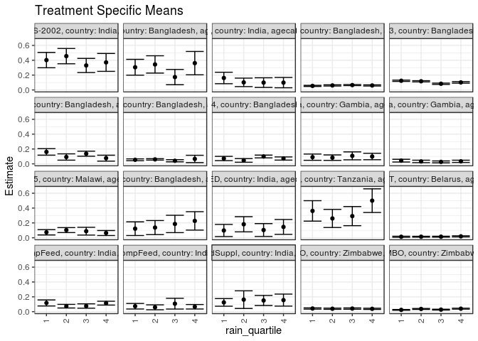

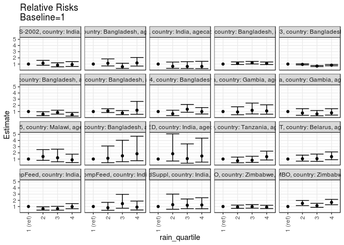

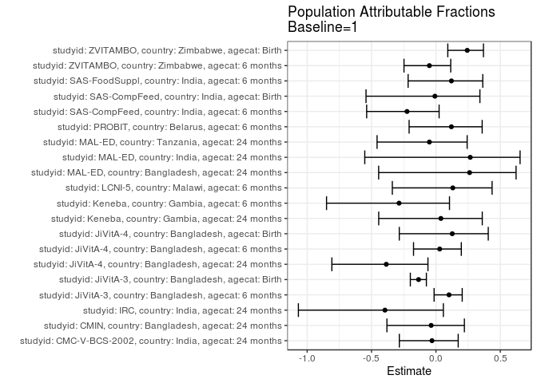

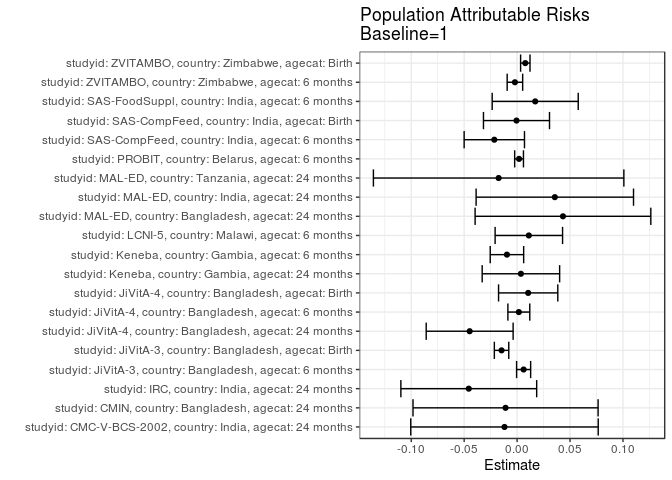

## Results Table

### Parameter: TSM

| studyid | country | agecat | intervention_level | baseline_level | estimate | ci_lower | ci_upper |
| --- | --- | --- | --- | --- | --- | --- | --- |
| CMC-V-BCS-2002 | India | 24 months | 1 | NA | 0.4022989 | 0.2991040 | 0.5054937 |
| CMC-V-BCS-2002 | India | 24 months | 2 | NA | 0.4555556 | 0.3525104 | 0.5586007 |
| CMC-V-BCS-2002 | India | 24 months | 3 | NA | 0.3297872 | 0.2346040 | 0.4249705 |
| CMC-V-BCS-2002 | India | 24 months | 4 | NA | 0.3709677 | 0.2505446 | 0.4913909 |
| CMIN | Bangladesh | 24 months | 1 | NA | 0.3055556 | 0.1989163 | 0.4121949 |
| CMIN | Bangladesh | 24 months | 2 | NA | 0.3437500 | 0.2271266 | 0.4603734 |
| CMIN | Bangladesh | 24 months | 3 | NA | 0.1730769 | 0.0700217 | 0.2761322 |
| CMIN | Bangladesh | 24 months | 4 | NA | 0.3611111 | 0.2038572 | 0.5183650 |
| IRC | India | 24 months | 1 | NA | 0.1609195 | 0.0835943 | 0.2382448 |
| IRC | India | 24 months | 2 | NA | 0.1018519 | 0.0447275 | 0.1589762 |
| IRC | India | 24 months | 3 | NA | 0.0987654 | 0.0336995 | 0.1638314 |
| IRC | India | 24 months | 4 | NA | 0.0985916 | 0.0291489 | 0.1680342 |
| JiVitA-3 | Bangladesh | Birth | 1 | NA | 0.1237035 | 0.1152388 | 0.1321682 |
| JiVitA-3 | Bangladesh | Birth | 2 | NA | 0.1166225 | 0.1085493 | 0.1246958 |
| JiVitA-3 | Bangladesh | Birth | 3 | NA | 0.0832614 | 0.0742528 | 0.0922701 |
| JiVitA-3 | Bangladesh | Birth | 4 | NA | 0.1013216 | 0.0910013 | 0.1116419 |
| JiVitA-3 | Bangladesh | 6 months | 1 | NA | 0.0545113 | 0.0471668 | 0.0618558 |
| JiVitA-3 | Bangladesh | 6 months | 2 | NA | 0.0607750 | 0.0526590 | 0.0688911 |
| JiVitA-3 | Bangladesh | 6 months | 3 | NA | 0.0652757 | 0.0582298 | 0.0723215 |
| JiVitA-3 | Bangladesh | 6 months | 4 | NA | 0.0603368 | 0.0525409 | 0.0681326 |
| JiVitA-4 | Bangladesh | Birth | 1 | NA | 0.0720721 | 0.0432026 | 0.1009416 |
| JiVitA-4 | Bangladesh | Birth | 2 | NA | 0.0462963 | 0.0217698 | 0.0708228 |
| JiVitA-4 | Bangladesh | Birth | 3 | NA | 0.0990854 | 0.0805090 | 0.1176617 |
| JiVitA-4 | Bangladesh | Birth | 4 | NA | 0.0717256 | 0.0503261 | 0.0931251 |
| JiVitA-4 | Bangladesh | 6 months | 1 | NA | 0.0544588 | 0.0419608 | 0.0669568 |
| JiVitA-4 | Bangladesh | 6 months | 2 | NA | 0.0600842 | 0.0505612 | 0.0696072 |
| JiVitA-4 | Bangladesh | 6 months | 3 | NA | 0.0414013 | 0.0269950 | 0.0558076 |
| JiVitA-4 | Bangladesh | 6 months | 4 | NA | 0.0661157 | 0.0169470 | 0.1152844 |
| JiVitA-4 | Bangladesh | 24 months | 1 | NA | 0.1609756 | 0.1169850 | 0.2049662 |
| JiVitA-4 | Bangladesh | 24 months | 2 | NA | 0.0923077 | 0.0498363 | 0.1347791 |
| JiVitA-4 | Bangladesh | 24 months | 3 | NA | 0.1365385 | 0.1028609 | 0.1702160 |
| JiVitA-4 | Bangladesh | 24 months | 4 | NA | 0.0763723 | 0.0362943 | 0.1164503 |
| Keneba | Gambia | 6 months | 1 | NA | 0.0431034 | 0.0246201 | 0.0615868 |
| Keneba | Gambia | 6 months | 2 | NA | 0.0326797 | 0.0164104 | 0.0489491 |
| Keneba | Gambia | 6 months | 3 | NA | 0.0264026 | 0.0136345 | 0.0391708 |
| Keneba | Gambia | 6 months | 4 | NA | 0.0339286 | 0.0189302 | 0.0489270 |
| Keneba | Gambia | 24 months | 1 | NA | 0.0898876 | 0.0478398 | 0.1319355 |
| Keneba | Gambia | 24 months | 2 | NA | 0.0833333 | 0.0464488 | 0.1202179 |
| Keneba | Gambia | 24 months | 3 | NA | 0.1076923 | 0.0543669 | 0.1610177 |
| Keneba | Gambia | 24 months | 4 | NA | 0.0989011 | 0.0554994 | 0.1423028 |
| LCNI-5 | Malawi | 6 months | 1 | NA | 0.0735294 | 0.0376919 | 0.1093670 |
| LCNI-5 | Malawi | 6 months | 2 | NA | 0.1034483 | 0.0700087 | 0.1368879 |
| LCNI-5 | Malawi | 6 months | 3 | NA | 0.0884956 | 0.0360984 | 0.1408928 |
| LCNI-5 | Malawi | 6 months | 4 | NA | 0.0640394 | 0.0303408 | 0.0977380 |
| MAL-ED | Bangladesh | 24 months | 1 | NA | 0.1224490 | 0.0304192 | 0.2144787 |
| MAL-ED | Bangladesh | 24 months | 2 | NA | 0.1372549 | 0.0425587 | 0.2319511 |
| MAL-ED | Bangladesh | 24 months | 3 | NA | 0.1860465 | 0.0694223 | 0.3026707 |
| MAL-ED | Bangladesh | 24 months | 4 | NA | 0.2272727 | 0.1031153 | 0.3514302 |
| MAL-ED | India | 24 months | 1 | NA | 0.0980392 | 0.0162239 | 0.1798545 |
| MAL-ED | India | 24 months | 2 | NA | 0.1818182 | 0.0796330 | 0.2840034 |
| MAL-ED | India | 24 months | 3 | NA | 0.1041667 | 0.0175337 | 0.1907996 |
| MAL-ED | India | 24 months | 4 | NA | 0.1458333 | 0.0457401 | 0.2459266 |
| MAL-ED | Tanzania | 24 months | 1 | NA | 0.3617021 | 0.2239570 | 0.4994473 |
| MAL-ED | Tanzania | 24 months | 2 | NA | 0.2600000 | 0.1380855 | 0.3819145 |
| MAL-ED | Tanzania | 24 months | 3 | NA | 0.2916667 | 0.1627291 | 0.4206043 |
| MAL-ED | Tanzania | 24 months | 4 | NA | 0.5000000 | 0.3405898 | 0.6594102 |
| PROBIT | Belarus | 6 months | 1 | NA | 0.0135659 | 0.0062607 | 0.0208711 |
| PROBIT | Belarus | 6 months | 2 | NA | 0.0141161 | 0.0079421 | 0.0202901 |
| PROBIT | Belarus | 6 months | 3 | NA | 0.0144060 | 0.0079183 | 0.0208938 |
| PROBIT | Belarus | 6 months | 4 | NA | 0.0188053 | 0.0114648 | 0.0261458 |
| SAS-CompFeed | India | Birth | 1 | NA | 0.0732601 | 0.0360460 | 0.1104741 |
| SAS-CompFeed | India | Birth | 2 | NA | 0.0588235 | 0.0256265 | 0.0920206 |
| SAS-CompFeed | India | Birth | 3 | NA | 0.1076233 | 0.0353879 | 0.1798587 |
| SAS-CompFeed | India | Birth | 4 | NA | 0.0660920 | 0.0357169 | 0.0964670 |
| SAS-CompFeed | India | 6 months | 1 | NA | 0.1173333 | 0.0766185 | 0.1580482 |
| SAS-CompFeed | India | 6 months | 2 | NA | 0.0739130 | 0.0496116 | 0.0982145 |
| SAS-CompFeed | India | 6 months | 3 | NA | 0.0760369 | 0.0467941 | 0.1052796 |
| SAS-CompFeed | India | 6 months | 4 | NA | 0.1144781 | 0.0885942 | 0.1403620 |
| SAS-FoodSuppl | India | 6 months | 1 | NA | 0.1250000 | 0.0736880 | 0.1763120 |
| SAS-FoodSuppl | India | 6 months | 2 | NA | 0.1621622 | 0.0432369 | 0.2810874 |
| SAS-FoodSuppl | India | 6 months | 3 | NA | 0.1509434 | 0.0827028 | 0.2191840 |
| SAS-FoodSuppl | India | 6 months | 4 | NA | 0.1558442 | 0.0747235 | 0.2369648 |
| ZVITAMBO | Zimbabwe | Birth | 1 | NA | 0.0241093 | 0.0191886 | 0.0290300 |
| ZVITAMBO | Zimbabwe | Birth | 2 | NA | 0.0364732 | 0.0299295 | 0.0430169 |
| ZVITAMBO | Zimbabwe | Birth | 3 | NA | 0.0274964 | 0.0220435 | 0.0329492 |
| ZVITAMBO | Zimbabwe | Birth | 4 | NA | 0.0401811 | 0.0337062 | 0.0466560 |
| ZVITAMBO | Zimbabwe | 6 months | 1 | NA | 0.0425532 | 0.0340444 | 0.0510620 |
| ZVITAMBO | Zimbabwe | 6 months | 2 | NA | 0.0395204 | 0.0314732 | 0.0475676 |
| ZVITAMBO | Zimbabwe | 6 months | 3 | NA | 0.0417288 | 0.0329928 | 0.0504648 |
| ZVITAMBO | Zimbabwe | 6 months | 4 | NA | 0.0383586 | 0.0304081 | 0.0463091 |

### Parameter: E(Y)

| studyid | country | agecat | intervention_level | baseline_level | estimate | ci_lower | ci_upper |
| --- | --- | --- | --- | --- | --- | --- | --- |
| CMC-V-BCS-2002 | India | 24 months | NA | NA | 0.3903904 | 0.3379151 | 0.4428656 |
| CMIN | Bangladesh | 24 months | NA | NA | 0.2946429 | 0.2348088 | 0.3544769 |
| IRC | India | 24 months | NA | NA | 0.1152738 | 0.0816242 | 0.1489234 |
| JiVitA-3 | Bangladesh | Birth | NA | NA | 0.1090180 | 0.1044666 | 0.1135695 |
| JiVitA-3 | Bangladesh | 6 months | NA | NA | 0.0606746 | 0.0568229 | 0.0645262 |
| JiVitA-4 | Bangladesh | Birth | NA | NA | 0.0825363 | 0.0708486 | 0.0942240 |
| JiVitA-4 | Bangladesh | 6 months | NA | NA | 0.0560960 | 0.0493335 | 0.0628586 |
| JiVitA-4 | Bangladesh | 24 months | NA | NA | 0.1161695 | 0.0947482 | 0.1375909 |
| Keneba | Gambia | 6 months | NA | NA | 0.0335089 | 0.0257898 | 0.0412279 |
| Keneba | Gambia | 24 months | NA | NA | 0.0934844 | 0.0719957 | 0.1149732 |
| LCNI-5 | Malawi | 6 months | NA | NA | 0.0846246 | 0.0657805 | 0.1034686 |
| MAL-ED | Bangladesh | 24 months | NA | NA | 0.1657754 | 0.1123321 | 0.2192187 |
| MAL-ED | India | 24 months | NA | NA | 0.1336634 | 0.0866199 | 0.1807069 |
| MAL-ED | Tanzania | 24 months | NA | NA | 0.3442623 | 0.2752348 | 0.4132898 |
| PROBIT | Belarus | 6 months | NA | NA | 0.0154178 | 0.0100323 | 0.0208033 |
| SAS-CompFeed | India | Birth | NA | NA | 0.0726837 | 0.0523147 | 0.0930527 |
| SAS-CompFeed | India | 6 months | NA | NA | 0.0958084 | 0.0774939 | 0.1141229 |
| SAS-FoodSuppl | India | 6 months | NA | NA | 0.1421053 | 0.1069532 | 0.1772573 |
| ZVITAMBO | Zimbabwe | Birth | NA | NA | 0.0318559 | 0.0289336 | 0.0347781 |
| ZVITAMBO | Zimbabwe | 6 months | NA | NA | 0.0404891 | 0.0363397 | 0.0446385 |

### Parameter: RR

| studyid | country | agecat | intervention_level | baseline_level | estimate | ci_lower | ci_upper |
| --- | --- | --- | --- | --- | --- | --- | --- |
| CMC-V-BCS-2002 | India | 24 months | 1 | 1 | 1.0000000 | 1.0000000 | 1.0000000 |
| CMC-V-BCS-2002 | India | 24 months | 2 | 1 | 1.1323810 | 0.8043851 | 1.5941204 |
| CMC-V-BCS-2002 | India | 24 months | 3 | 1 | 0.8197568 | 0.5571712 | 1.2060949 |
| CMC-V-BCS-2002 | India | 24 months | 4 | 1 | 0.9221198 | 0.6096839 | 1.3946652 |
| CMIN | Bangladesh | 24 months | 1 | 1 | 1.0000000 | 1.0000000 | 1.0000000 |
| CMIN | Bangladesh | 24 months | 2 | 1 | 1.1250000 | 0.6914630 | 1.8303581 |
| CMIN | Bangladesh | 24 months | 3 | 1 | 0.5664336 | 0.2840603 | 1.1295032 |
| CMIN | Bangladesh | 24 months | 4 | 1 | 1.1818182 | 0.6763718 | 2.0649800 |
| IRC | India | 24 months | 1 | 1 | 1.0000000 | 1.0000000 | 1.0000000 |
| IRC | India | 24 months | 2 | 1 | 0.6329365 | 0.3024199 | 1.3246769 |
| IRC | India | 24 months | 3 | 1 | 0.6137566 | 0.2715590 | 1.3871653 |
| IRC | India | 24 months | 4 | 1 | 0.6126761 | 0.2611749 | 1.4372435 |
| JiVitA-3 | Bangladesh | Birth | 1 | 1 | 1.0000000 | 1.0000000 | 1.0000000 |
| JiVitA-3 | Bangladesh | Birth | 2 | 1 | 0.9427588 | 0.8586242 | 1.0351376 |
| JiVitA-3 | Bangladesh | Birth | 3 | 1 | 0.6730727 | 0.5937963 | 0.7629331 |
| JiVitA-3 | Bangladesh | Birth | 4 | 1 | 0.8190682 | 0.7236642 | 0.9270498 |
| JiVitA-3 | Bangladesh | 6 months | 1 | 1 | 1.0000000 | 1.0000000 | 1.0000000 |
| JiVitA-3 | Bangladesh | 6 months | 2 | 1 | 1.1149073 | 0.9243825 | 1.3447012 |
| JiVitA-3 | Bangladesh | 6 months | 3 | 1 | 1.1974706 | 1.0080955 | 1.4224205 |
| JiVitA-3 | Bangladesh | 6 months | 4 | 1 | 1.1068675 | 0.9186408 | 1.3336613 |
| JiVitA-4 | Bangladesh | Birth | 1 | 1 | 1.0000000 | 1.0000000 | 1.0000000 |
| JiVitA-4 | Bangladesh | Birth | 2 | 1 | 0.6423611 | 0.3406403 | 1.2113299 |
| JiVitA-4 | Bangladesh | Birth | 3 | 1 | 1.3748095 | 0.8804568 | 2.1467278 |
| JiVitA-4 | Bangladesh | Birth | 4 | 1 | 0.9951923 | 0.6004630 | 1.6494068 |
| JiVitA-4 | Bangladesh | 6 months | 1 | 1 | 1.0000000 | 1.0000000 | 1.0000000 |
| JiVitA-4 | Bangladesh | 6 months | 2 | 1 | 1.1032960 | 0.8370163 | 1.4542873 |
| JiVitA-4 | Bangladesh | 6 months | 3 | 1 | 0.7602310 | 0.4961806 | 1.1647998 |
| JiVitA-4 | Bangladesh | 6 months | 4 | 1 | 1.2140496 | 0.5573983 | 2.6442787 |
| JiVitA-4 | Bangladesh | 24 months | 1 | 1 | 1.0000000 | 1.0000000 | 1.0000000 |
| JiVitA-4 | Bangladesh | 24 months | 2 | 1 | 0.5734266 | 0.3385773 | 0.9711756 |
| JiVitA-4 | Bangladesh | 24 months | 3 | 1 | 0.8481935 | 0.5907894 | 1.2177473 |
| JiVitA-4 | Bangladesh | 24 months | 4 | 1 | 0.4744341 | 0.2661091 | 0.8458474 |
| Keneba | Gambia | 6 months | 1 | 1 | 1.0000000 | 1.0000000 | 1.0000000 |
| Keneba | Gambia | 6 months | 2 | 1 | 0.7581699 | 0.3930147 | 1.4625959 |
| Keneba | Gambia | 6 months | 3 | 1 | 0.6125413 | 0.3209494 | 1.1690527 |
| Keneba | Gambia | 6 months | 4 | 1 | 0.7871429 | 0.4251909 | 1.4572135 |
| Keneba | Gambia | 24 months | 1 | 1 | 1.0000000 | 1.0000000 | 1.0000000 |
| Keneba | Gambia | 24 months | 2 | 1 | 0.9270833 | 0.4868959 | 1.7652307 |
| Keneba | Gambia | 24 months | 3 | 1 | 1.1980769 | 0.6062498 | 2.3676517 |
| Keneba | Gambia | 24 months | 4 | 1 | 1.1002747 | 0.5793521 | 2.0895834 |
| LCNI-5 | Malawi | 6 months | 1 | 1 | 1.0000000 | 1.0000000 | 1.0000000 |
| LCNI-5 | Malawi | 6 months | 2 | 1 | 1.4068966 | 0.7839143 | 2.5249671 |
| LCNI-5 | Malawi | 6 months | 3 | 1 | 1.2035398 | 0.5589912 | 2.5912898 |
| LCNI-5 | Malawi | 6 months | 4 | 1 | 0.8709360 | 0.4250958 | 1.7843729 |
| MAL-ED | Bangladesh | 24 months | 1 | 1 | 1.0000000 | 1.0000000 | 1.0000000 |
| MAL-ED | Bangladesh | 24 months | 2 | 1 | 1.1209150 | 0.4041033 | 3.1092308 |
| MAL-ED | Bangladesh | 24 months | 3 | 1 | 1.5193798 | 0.5709935 | 4.0429800 |
| MAL-ED | Bangladesh | 24 months | 4 | 1 | 1.8560606 | 0.7329451 | 4.7001625 |
| MAL-ED | India | 24 months | 1 | 1 | 1.0000000 | 1.0000000 | 1.0000000 |
| MAL-ED | India | 24 months | 2 | 1 | 1.8545454 | 0.6780852 | 5.0721338 |
| MAL-ED | India | 24 months | 3 | 1 | 1.0625000 | 0.3270792 | 3.4514764 |
| MAL-ED | India | 24 months | 4 | 1 | 1.4875000 | 0.5048916 | 4.3824377 |
| MAL-ED | Tanzania | 24 months | 1 | 1 | 1.0000000 | 1.0000000 | 1.0000000 |
| MAL-ED | Tanzania | 24 months | 2 | 1 | 0.7188235 | 0.3928977 | 1.3151193 |
| MAL-ED | Tanzania | 24 months | 3 | 1 | 0.8063725 | 0.4499159 | 1.4452405 |
| MAL-ED | Tanzania | 24 months | 4 | 1 | 1.3823529 | 0.8412421 | 2.2715216 |
| PROBIT | Belarus | 6 months | 1 | 1 | 1.0000000 | 1.0000000 | 1.0000000 |
| PROBIT | Belarus | 6 months | 2 | 1 | 1.0405610 | 0.6636563 | 1.6315179 |
| PROBIT | Belarus | 6 months | 3 | 1 | 1.0619301 | 0.6270341 | 1.7984597 |
| PROBIT | Belarus | 6 months | 4 | 1 | 1.3862200 | 0.8913239 | 2.1559007 |
| SAS-CompFeed | India | Birth | 1 | 1 | 1.0000000 | 1.0000000 | 1.0000000 |
| SAS-CompFeed | India | Birth | 2 | 1 | 0.8029412 | 0.3851949 | 1.6737360 |
| SAS-CompFeed | India | Birth | 3 | 1 | 1.4690583 | 0.7255009 | 2.9746789 |
| SAS-CompFeed | India | Birth | 4 | 1 | 0.9021552 | 0.4333698 | 1.8780359 |
| SAS-CompFeed | India | 6 months | 1 | 1 | 1.0000000 | 1.0000000 | 1.0000000 |
| SAS-CompFeed | India | 6 months | 2 | 1 | 0.6299407 | 0.4173414 | 0.9508410 |
| SAS-CompFeed | India | 6 months | 3 | 1 | 0.6480415 | 0.4087774 | 1.0273506 |
| SAS-CompFeed | India | 6 months | 4 | 1 | 0.9756657 | 0.6470893 | 1.4710855 |
| SAS-FoodSuppl | India | 6 months | 1 | 1 | 1.0000000 | 1.0000000 | 1.0000000 |
| SAS-FoodSuppl | India | 6 months | 2 | 1 | 1.2972973 | 0.5598095 | 3.0063448 |
| SAS-FoodSuppl | India | 6 months | 3 | 1 | 1.2075472 | 0.6556940 | 2.2238577 |
| SAS-FoodSuppl | India | 6 months | 4 | 1 | 1.2467532 | 0.6425121 | 2.4192440 |
| ZVITAMBO | Zimbabwe | Birth | 1 | 1 | 1.0000000 | 1.0000000 | 1.0000000 |
| ZVITAMBO | Zimbabwe | Birth | 2 | 1 | 1.5128273 | 1.1528490 | 1.9852091 |
| ZVITAMBO | Zimbabwe | Birth | 3 | 1 | 1.1404888 | 0.8580265 | 1.5159377 |
| ZVITAMBO | Zimbabwe | Birth | 4 | 1 | 1.6666226 | 1.2849922 | 2.1615937 |
| ZVITAMBO | Zimbabwe | 6 months | 1 | 1 | 1.0000000 | 1.0000000 | 1.0000000 |
| ZVITAMBO | Zimbabwe | 6 months | 2 | 1 | 0.9287300 | 0.6981498 | 1.2354647 |
| ZVITAMBO | Zimbabwe | 6 months | 3 | 1 | 0.9806259 | 0.7341325 | 1.3098824 |
| ZVITAMBO | Zimbabwe | 6 months | 4 | 1 | 0.9014273 | 0.6758574 | 1.2022820 |

### Parameter: PAR

| studyid | country | agecat | intervention_level | baseline_level | estimate | ci_lower | ci_upper |
| --- | --- | --- | --- | --- | --- | --- | --- |
| CMC-V-BCS-2002 | India | 24 months | 1 | NA | -0.0119085 | -0.1004432 | 0.0766262 |
| CMIN | Bangladesh | 24 months | 1 | NA | -0.0109127 | -0.0983285 | 0.0765031 |
| IRC | India | 24 months | 1 | NA | -0.0456458 | -0.1097806 | 0.0184891 |
| JiVitA-3 | Bangladesh | Birth | 1 | NA | -0.0146854 | -0.0214927 | -0.0078781 |
| JiVitA-3 | Bangladesh | 6 months | 1 | NA | 0.0061633 | -0.0004686 | 0.0127952 |
| JiVitA-4 | Bangladesh | Birth | 1 | NA | 0.0104642 | -0.0175107 | 0.0384392 |
| JiVitA-4 | Bangladesh | 6 months | 1 | NA | 0.0016372 | -0.0087008 | 0.0119753 |
| JiVitA-4 | Bangladesh | 24 months | 1 | NA | -0.0448061 | -0.0858589 | -0.0037533 |
| Keneba | Gambia | 6 months | 1 | NA | -0.0095946 | -0.0253887 | 0.0061995 |
| Keneba | Gambia | 24 months | 1 | NA | 0.0035968 | -0.0329855 | 0.0401790 |
| LCNI-5 | Malawi | 6 months | 1 | NA | 0.0110951 | -0.0207618 | 0.0429521 |
| MAL-ED | Bangladesh | 24 months | 1 | NA | 0.0433264 | -0.0396622 | 0.1263150 |
| MAL-ED | India | 24 months | 1 | NA | 0.0356241 | -0.0387185 | 0.1099668 |
| MAL-ED | Tanzania | 24 months | 1 | NA | -0.0174398 | -0.1357295 | 0.1008499 |
| PROBIT | Belarus | 6 months | 1 | NA | 0.0018519 | -0.0022996 | 0.0060035 |
| SAS-CompFeed | India | Birth | 1 | NA | -0.0005764 | -0.0317676 | 0.0306149 |
| SAS-CompFeed | India | 6 months | 1 | NA | -0.0215250 | -0.0500183 | 0.0069684 |
| SAS-FoodSuppl | India | 6 months | 1 | NA | 0.0171053 | -0.0235321 | 0.0577426 |
| ZVITAMBO | Zimbabwe | Birth | 1 | NA | 0.0077466 | 0.0033054 | 0.0121877 |
| ZVITAMBO | Zimbabwe | 6 months | 1 | NA | -0.0020641 | -0.0093788 | 0.0052506 |

### Parameter: PAF

| studyid | country | agecat | intervention_level | baseline_level | estimate | ci_lower | ci_upper |
| --- | --- | --- | --- | --- | --- | --- | --- |
| CMC-V-BCS-2002 | India | 24 months | 1 | NA | -0.0305040 | -0.2841942 | 0.1730702 |
| CMIN | Bangladesh | 24 months | 1 | NA | -0.0370370 | -0.3804967 | 0.2209718 |
| IRC | India | 24 months | 1 | NA | -0.3959770 | -1.0681121 | 0.0577146 |
| JiVitA-3 | Bangladesh | Birth | 1 | NA | -0.1347065 | -0.1987251 | -0.0741069 |
| JiVitA-3 | Bangladesh | 6 months | 1 | NA | 0.1015793 | -0.0141697 | 0.2041177 |
| JiVitA-4 | Bangladesh | Birth | 1 | NA | 0.1267834 | -0.2845685 | 0.4064099 |
| JiVitA-4 | Bangladesh | 6 months | 1 | NA | 0.0291862 | -0.1739089 | 0.1971444 |
| JiVitA-4 | Bangladesh | 24 months | 1 | NA | -0.3856955 | -0.8080581 | -0.0619968 |
| Keneba | Gambia | 6 months | 1 | NA | -0.2863300 | -0.8495341 | 0.1053720 |
| Keneba | Gambia | 24 months | 1 | NA | 0.0384746 | -0.4443509 | 0.3598986 |
| LCNI-5 | Malawi | 6 months | 1 | NA | 0.1311102 | -0.3385954 | 0.4359987 |
| MAL-ED | Bangladesh | 24 months | 1 | NA | 0.2613562 | -0.4448207 | 0.6223789 |
| MAL-ED | India | 24 months | 1 | NA | 0.2665214 | -0.5526260 | 0.6534962 |
| MAL-ED | Tanzania | 24 months | 1 | NA | -0.0506586 | -0.4571291 | 0.2424258 |
| PROBIT | Belarus | 6 months | 1 | NA | 0.1201152 | -0.2082543 | 0.3592431 |
| SAS-CompFeed | India | Birth | 1 | NA | -0.0079298 | -0.5429098 | 0.3415542 |
| SAS-CompFeed | India | 6 months | 1 | NA | -0.2246667 | -0.5379087 | 0.0247740 |
| SAS-FoodSuppl | India | 6 months | 1 | NA | 0.1203704 | -0.2160319 | 0.3637105 |
| ZVITAMBO | Zimbabwe | Birth | 1 | NA | 0.2431754 | 0.0921440 | 0.3690811 |
| ZVITAMBO | Zimbabwe | 6 months | 1 | NA | -0.0509790 | -0.2480123 | 0.1149472 |